# CNN Autoencoder implementation

## CSCI8110: Assignment 1

### Submitted by: Sinan Rasiya Koya

### Implement a convolutional Autoencoder and discuss your discovery/thinking during the implementation.

### *Network Structure and Data*: We may reuse the structure discussed in class (Lecture 4), but this time, let's reconstruct the Cifar10 small image data. We may not need to use "y_train" and "y_test" in this case as we are implementing an autoencoder. We can use only a part the 50,000 training images if you believe the dataset is too large for you.

### *Optimizer and Loss*: let's use an optimizer "adam", and loss "mae".

### *Bonus*: we may tune the discussed structure in class, thus, you can try to add more layers or remove some layers and observe the results

### This notebook contains runnable codes with explanation, visualizations of inputs and outputs, and discussion of results.

## SECTION 1: Runnable codes

### Let us first import required libraries

```python
import numpy as np
import tensorflow as tf

from keras.layers import Input, Dense, Conv2D, MaxPooling2D, UpSampling2D, Flatten, Reshape
from keras.models import Model
from keras.datasets import cifar10

import matplotlib.pyplot as plt
```

### Let us load the cifar10 data, which we can directly do using keras datasets (we already imported it)

```python
(x_train, y_train), (x_test, y_test) = cifar10.load_data()
```

### To get an idea, let's print the shape of dataset and plot one image in the dataset

```
(50000, 32, 32, 3)
```

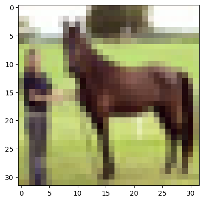

```python
print(x_train.shape)
plt.imshow(x_train[1729])
```

### In this work, I plan to test three structures of convolutional autoencoder. 1) Basic structure discussed in class, 2) Adding one convolutional layer to both encoder and decoder of basic structure 3) Adding one dense layer to both encoder and decoder of basic structure

## Structure 1: Basic structure discussed in class

### Let us define the Model. The basic structure discussed in class 3 covolutional layers (followed by maxpooling or upsampling layers) in both encoder and decoder parts of convolutional autoencoder.

```python
image_in = Input(shape=(32,32,3))

x = Conv2D(64, (3,3),
           activation='relu',
           padding='same')(image_in)
x = MaxPooling2D((2,2),
                 padding='same')(x)
x = Conv2D(32,(3,3),
           activation='relu',
           padding='same')(x)
x = MaxPooling2D((2,2),
                 padding='same')(x)
x = Conv2D(16,(3,3),
           activation='relu',
           padding='same')(x)
image_encode = MaxPooling2D((2,2),
                          padding='same')(x)

x = Conv2D(16,(3,3),
           activation='relu',
           padding='same')(image_encode)
x = UpSampling2D((2,2))(x)
x = Conv2D(32,(3,3),
           activation='relu',
           padding='same')(x)
x = UpSampling2D((2,2))(x)
x = Conv2D(64,(3,3),
           activation='relu',
           padding='same')(x)
x = UpSampling2D((2,2))(x)
image_decode =  Conv2D(3,(3,3),
                       activation='sigmoid',
                       padding='same')(x)

cnnae_s1 = Model(image_in,image_decode)
cnnae_s1.compile(optimizer='adam', loss='mae')
cnnae_s1.summary()
```

[output not shown]

### Now we train the model using .fit()

### Here I use only 1000 samples with ten epochs to check if training is running without error

```python
cnnae_s1.fit(x = x_train[:1000],
            y = x_train[:1000],
            epochs = 10,
            batch_size = 128,
            shuffle=True)
```

```
<keras.callbacks.History at 0x1a95066c430>
```

```python
x_train = x_train.astype('float32')/255
x_test = x_test.astype('float32')/255
```

### Let us initialize and train the model again, now with 50 epochs of 10000 samples as batches of 128 (this configuration is used in all structures).

```python
cnnae_s1 = Model(image_in,image_decode)
cnnae_s1.compile(optimizer='adam', loss='mae')

nsamples = 10000; nepochs=50; batchsize=128
cnnae_s1.fit(x = x_train[:nsamples],
             y = x_train[:nsamples],
             epochs = nepochs,
             batch_size = batchsize,
             shuffle=True)
```

```
<keras.callbacks.History at 0x1a95202b310>
```

### Pedict on test data

```python
preds_s1 = cnnae_s1.predict(x_test)
```

## Structure 2: Adding a convolutional layer to both encoder and decoder of basic sturcture

### Let us define the structure

```python
image_in = Input(shape=(32,32,3))

x = Conv2D(64, (3,3),
           activation='relu',
           padding='same')(image_in)
x = MaxPooling2D((2,2),
                 padding='same')(x)
x = Conv2D(32,(3,3),
           activation='relu',
           padding='same')(x)
x = MaxPooling2D((2,2),
                 padding='same')(x)
x = Conv2D(16,(3,3),
           activation='relu',
           padding='same')(x)
x = MaxPooling2D((2,2),
                 padding='same')(x)
x = Conv2D(8,(3,3), # Additional Layer in encoder
           activation='relu',
           padding='same')(x)
image_encode = MaxPooling2D((2,2),
                          padding='same')(x)
x = Conv2D(8,(3,3), # Additional Layer in decoder
           activation='relu',
           padding='same')(image_encode)
x = UpSampling2D((2,2))(x)
x = Conv2D(16,(3,3),
           activation='relu',
           padding='same')(x)
x = UpSampling2D((2,2))(x)
x = Conv2D(32,(3,3),
           activation='relu',
           padding='same')(x)
x = UpSampling2D((2,2))(x)
x = Conv2D(64,(3,3),
           activation='relu',
           padding='same')(x)
x = UpSampling2D((2,2))(x)
image_decode = Conv2D(3,(3,3),
                    activation='sigmoid',
                    padding='same')(x)

cnnae_s2 = Model(image_in,image_decode)
cnnae_s2.compile(optimizer='adam', loss='mae')
cnnae_s2.summary()
```

[output not shown]

[output cut: 14 more lines]

```
 up_sampling2d_5 (UpSampling  (None, 16, 16, 32)       0
 2D)

 conv2d_14 (Conv2D)          (None, 16, 16, 64)        18496

 up_sampling2d_6 (UpSampling  (None, 32, 32, 64)       0
 2D)

 conv2d_15 (Conv2D)          (None, 32, 32, 3)         1731

=================================================================
Total params: 52,659
Trainable params: 52,659
Non-trainable params: 0
_________________________________________________________________
```

### Train the model with 50 epochs of 10000 samples as batches of 128

```python
cnnae_s2.fit(x = x_train[:nsamples],
             y = x_train[:nsamples],
             epochs = nepochs,
             batch_size = batchsize,
             shuffle=True)
```

```
<keras.callbacks.History at 0x1a949bbaf10>
```

### Predict on test data

```python
preds_s2 = cnnae_s2.predict(x_test)
```

## Structure 3: Adding a dense layer to both encoder and decoder of basic sturcture

#### Define structure

```python
image_in = Input(shape=(32,32,3))

x = Conv2D(64, (3,3),
           activation='relu',
           padding='same')(image_in)
x = MaxPooling2D((2,2),
                 padding='same')(x)
x = Conv2D(32,(3,3),
           activation='relu',
           padding='same')(x)
x = MaxPooling2D((2,2),
                 padding='same')(x)
x = Conv2D(16,(3,3),
           activation='relu',
           padding='same')(x)
x = MaxPooling2D((2,2),
                          padding='same')(x)
x = Flatten()(x)
image_encode = Dense(4*4*16, activation='relu')(x) # Additional dense layer in encoder

x = Dense(4*4*16, activation='relu')(image_encode) # Additional dense layer in decoder
x = Reshape((4,4,16))(x)
x = Conv2D(16,(3,3),
           activation='relu',
           padding='same')(x)
x = UpSampling2D((2,2))(x)
x = Conv2D(32,(3,3),
           activation='relu',
           padding='same')(x)
x = UpSampling2D((2,2))(x)
x = Conv2D(64,(3,3),
           activation='relu',
           padding='same')(x)
x = UpSampling2D((2,2))(x)
image_decode = Conv2D(3,(3,3),
                    activation='sigmoid',
                    padding='same')(x)

cnnae_s3 = Model(image_in,image_decode)
cnnae_s3.compile(optimizer='adam', loss='mae')
cnnae_s3.summary()
```

[output not shown]

[output cut: 20 more lines]

```
 up_sampling2d_8 (UpSampling  (None, 16, 16, 32)       0
 2D)

 conv2d_21 (Conv2D)          (None, 16, 16, 64)        18496

 up_sampling2d_9 (UpSampling  (None, 32, 32, 64)       0
 2D)

 conv2d_22 (Conv2D)          (None, 32, 32, 3)         1731

=================================================================
Total params: 183,651
Trainable params: 183,651
Non-trainable params: 0
_________________________________________________________________
```

### Train the model with 50 epochs of 10000 sample as batches of 128

```python
cnnae_s3.fit(x = x_train[:nsamples],
             y = x_train[:nsamples],
             epochs = nepochs,
             batch_size = batchsize,
             shuffle=True)
```

```
<keras.callbacks.History at 0x1a94f663d90>
```

### Predict

```python
preds_s3 = cnnae_s3.predict(x_test)
```

## SECTION 2: Visualizing Inputs and Outputs

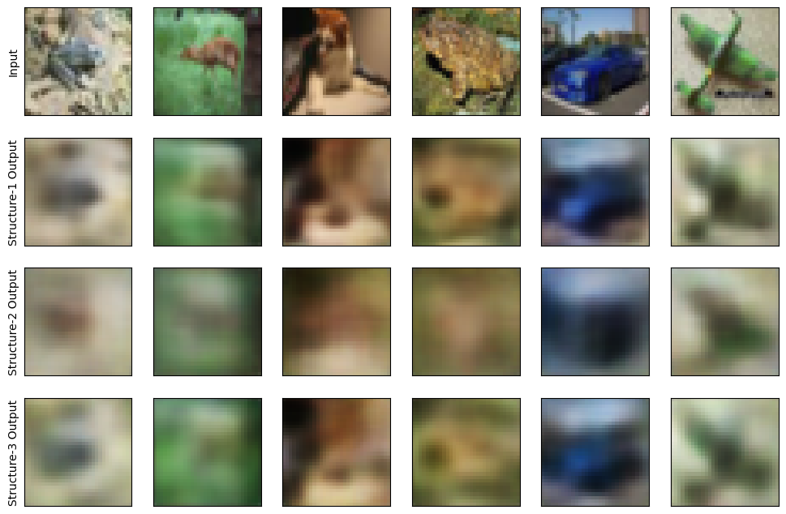

```python
nfigs = 6
fig, ax = plt.subplots(4,nfigs, figsize=(12,8), sharex=True, sharey=True)
ax = ax.flatten()
img_indices = np.random.randint(len(x_test), size = nfigs)
for i in range(nfigs):
    ax[i].imshow(x_test[img_indices[i]])
    ax[i].set_xticks([])
    ax[i].set_yticks([])

    ax[i+nfigs].imshow(preds_s1[img_indices[i]])
    ax[i+nfigs].set_xticks([])
    ax[i+nfigs].set_yticks([])

    ax[i+2*nfigs].imshow(preds_s2[img_indices[i]])
    ax[i+2*nfigs].set_xticks([])
    ax[i+2*nfigs].set_yticks([])

    ax[i+3*nfigs].imshow(preds_s3[img_indices[i]])
    ax[i+3*nfigs].set_xticks([])
    ax[i+3*nfigs].set_yticks([])

ax[0].set_ylabel('Input')
ax[nfigs].set_ylabel('Structure-1 Output')
ax[2*nfigs].set_ylabel('Structure-2 Output')
ax[3*nfigs].set_ylabel('Structure-3 Output')

plt.show()
```

## SECTION 3: Discussion

### Few other things I noticed during the implementation are:

### 1. It is important to normalize the data before training, as the model may not converge otherwise.

### 2. With an 8-core cpu, training a Convolutional Autoecoder with 50 epochs of 10000 samples as batches of 128 would take around 40 minutes to complete. A faster training can be achieved with GPU-based training.